# PA1_template

Roman Braun

04 12 2017

### Downloading and opening data

This document will download and analyze the [Activity Monitoring Data](https://d396qusza40orc.cloudfront.net/repdata%2Fdata%2Factivity.zip). First, set working directory and check for existence of the .zip file. Second, unzip the file to get access to activity.csv. Third, open csv and look at the data set.

```r
wd <- "/Users/romanbraun/Dropbox (Privat)/Coursera/Data Science/5_reproducible_research/W2 - assignment"
setwd(wd)
if (file.exists("repdata_data_activity.zip")) {
        unzip("repdata_data_activity.zip")
} else {
        download.file("https://d396qusza40orc.cloudfront.net/repdata%2Fdata%2Factivity.zip",
        "repdata_data_activity.zip")
        unzip("repdata_data_activity.zip")
}
df <- read.table("activity.csv", sep=",", header = TRUE)
#head(df)
#dim(df)
#as.Date(df$date[2])
df$date <- as.Date(df$date)
```

### Calculating mean number of steps per day

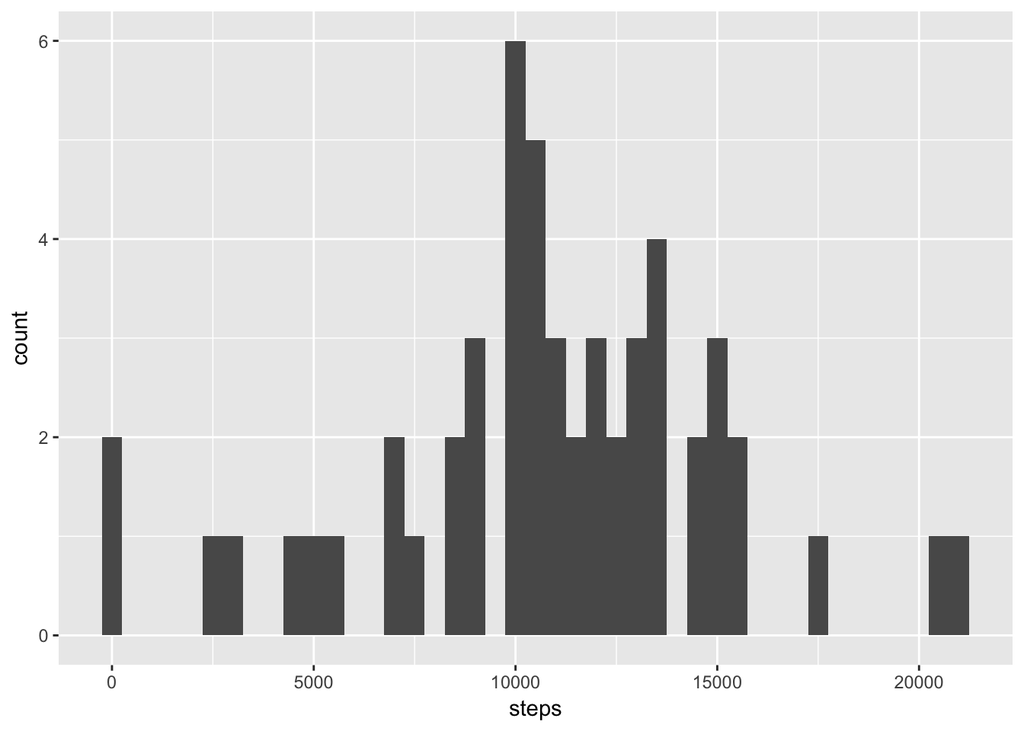

```r
steps_sum <- aggregate(steps ~ date, data = df, sum)
#dim(steps_sum)
#steps_sum
# Print steps per day as list
#steps_sum
library(ggplot2)
qplot(x = steps_sum$steps, xlab = "steps", binwidth = 500)
```

Figure 1: Distribution of sum of steps in dataset

Mean steps per day:

```r
mean(steps_sum$steps)
```

```
## [1] 10766.19
```

Median steps per day:

```r
median(steps_sum$steps)
```

```
## [1] 10765
```

### What is the daily pattern?

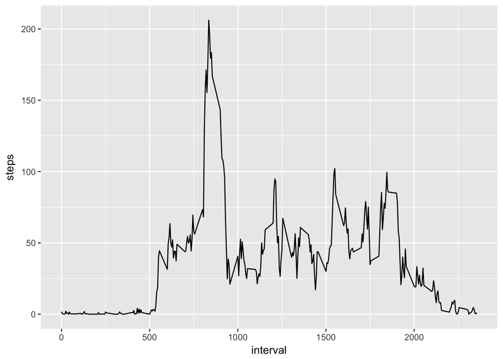

```r
#head(df)
#class(df)
steps_int <- aggregate(df, by=list(df$interval), FUN=mean, na.rm=TRUE)
#steps_int
ggplot(steps_int, aes(x = interval, y = steps)) +
        geom_line(stat="identity")
```

Figure 2: Daily pattern of steps throughout data set

Maximum of steps

```r
steps_int[which.max(steps_int$steps),c(1,2)]
```

```
##     Group.1    steps
## 104     835 206.1698
```

### Removing NA values

Replace NA values by ‘0’.

```r
dfnew <- df
dfnew$steps[is.na(dfnew$steps)] <- 0
sum(is.na(dfnew$steps))
```

```
## [1] 0
```

Histogram of total number of steps including imputed values:

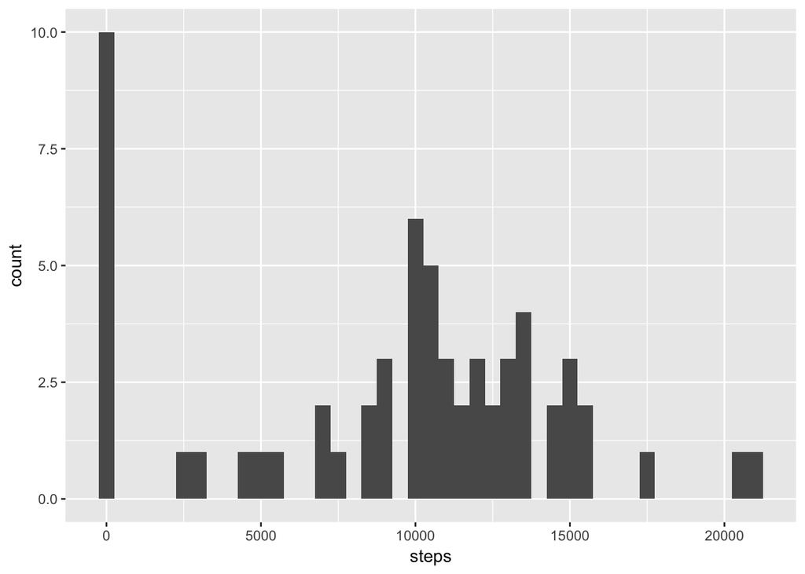

```r
steps_sum <- aggregate(steps ~ date, data = dfnew, sum)
library(ggplot2)
qplot(x = steps_sum$steps, xlab = "steps", binwidth = 500)
```

Figure 3: Distribution of number of steps after imputing missing values

Mean steps per day with imputed values:

```r
mean(steps_sum$steps)
```

```
## [1] 9354.23
```

Median steps per day with imputed values:

```r
median(steps_sum$steps)
```

```
## [1] 10395
```

### Are there differences in activity patterns between weekdays and weekends?

```r
df$weekday <- weekdays(as.Date(df$date))
mofr <- c("Montag", "Dienstag", "Mittwoch", "Donnerstag", "Freitag")
saso <- c("Samstag", "Sonntag")
df_week <- df[df$weekday == mofr,]
df_week <- subset(df, weekday %in% mofr)
df_wend <- subset(df, weekday %in% saso)
sel <- c("steps", "interval")
summary(df_week)
```

```
##      steps             date               interval        weekday
##  Min.   :  0.00   Min.   :2012-10-01   Min.   :   0.0   Length:12960
##  1st Qu.:  0.00   1st Qu.:2012-10-16   1st Qu.: 588.8   Class :character
##  Median :  0.00   Median :2012-10-31   Median :1177.5   Mode  :character
##  Mean   : 35.34   Mean   :2012-10-31   Mean   :1177.5
##  3rd Qu.:  8.00   3rd Qu.:2012-11-15   3rd Qu.:1766.2
##  Max.   :806.00   Max.   :2012-11-30   Max.   :2355.0
##  NA's   :1728
```

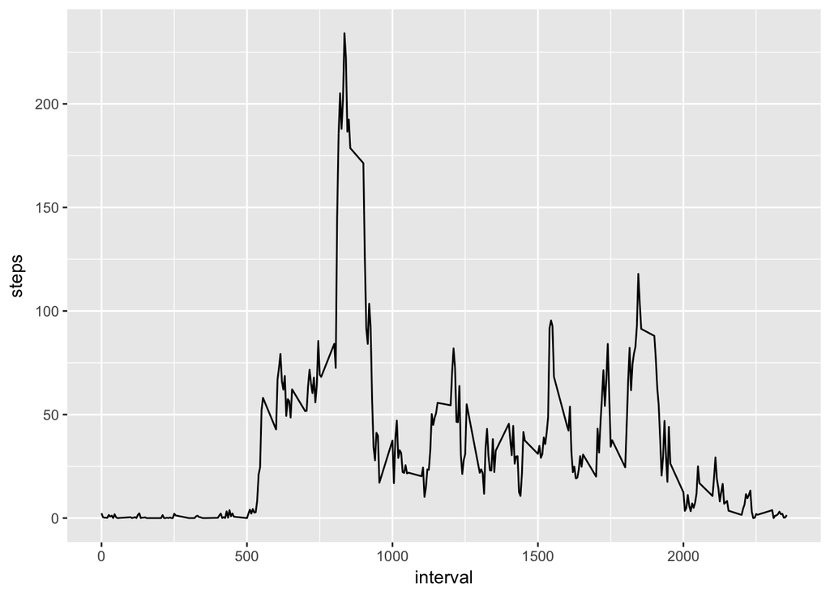

```r
df_week <- df_week[,sel]
#head(steps_week)
steps_week <- aggregate(df_week, by=list(df_week$interval), FUN=mean, na.rm=TRUE)
ggplot(steps_week, aes(x = interval, y = steps)) +
        geom_line(stat="identity")
```

Figure 4: Steps pattern on week days (Monday - Friday).

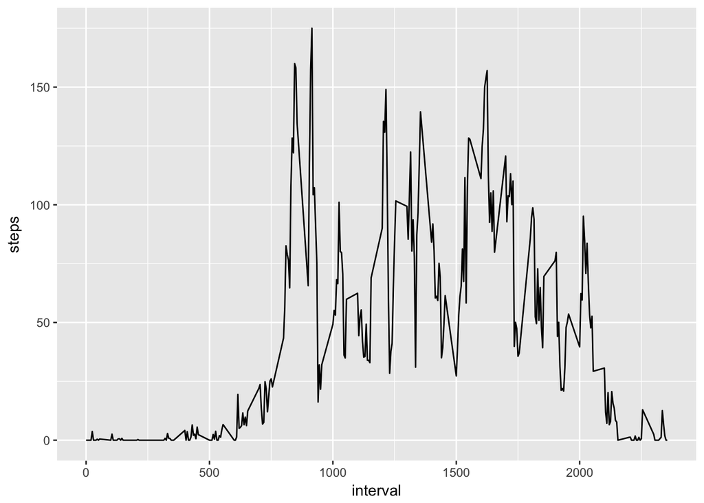

```r
df_wend <- df_wend[,sel]
steps_wend <- aggregate(df_wend, by=list(df_wend$interval), FUN=mean, na.rm=TRUE)
#steps_int
ggplot(steps_wend, aes(x = interval, y = steps)) +
        geom_line(stat="identity")
```

Figure 5: Steps pattern on weekend (Saturday / Sunday).

### Create new dataset

```r
write.table(dfnew, "activity_new.csv", sep =";", row.names = FALSE)
steps_sum_new <- aggregate(steps ~ date, data = dfnew, sum)
dim(steps_sum_new)
```

```
## [1] 61  2
```

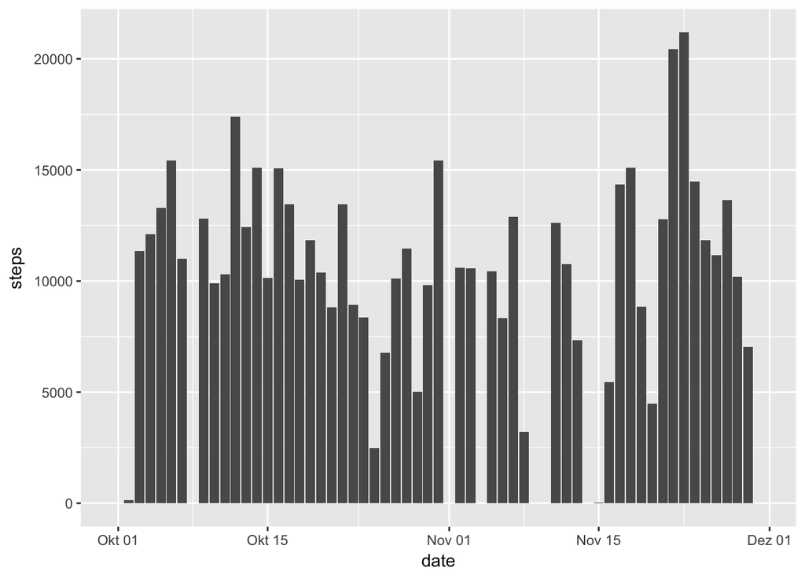

```r
# Print steps per day as list
#steps_sum


library(ggplot2)

ggplot(steps_sum_new, aes(x=date, y=steps)) +
        geom_bar(stat = "identity")
```